# Where Does Defensive Value Come From in MLS? A Look at Gameplan Style

Alex Bradley

2026-08-21

## Research Question

Where does defensive value come from in MLS, and does it differ between gameplan schemes?

This interests me because press intensity is often treated as a proxy for defensive quality in MLS analysis, but it’s rarely tested against where defensive value actually comes from. I wanted to see whether teams built around directness and aggressive counterpressing actually generate more defensive output, or whether that’s a narrative that doesn’t hold up in the data.

## Data Preparation

### Loading the data

Place the season CSV in a `data/` folder at the project root. It is **not** committed to git (see README).

```r
df <- read_csv("data/mls_events_2024.csv")
```

### First look

```r
glimpse(df)
```

```
## Rows: 1,872,701
## Columns: 73
## $ match_id_statsbomb             <dbl> 3926453, 3926461, 3926481, 3926462, 392…
## $ sb_id                          <chr> "8ed2676b-4967-5e35-abf4-3b28895a48fb",…
## $ sb_index                       <dbl> 4052, 2260, 1542, 1809, 2959, 3538, 128…
## $ period                         <dbl> 2, 2, 2, 1, 2, 2, 1, 1, 1, 2, 2, 2, 2, …
## $ match_date                     <date> 2024-03-23, 2024-03-24, 2024-04-07, 20…
## $ timestamp                      <time> 00:56:44, 00:09:25, 00:02:46, 00:37:09…
## $ minute                         <dbl> 101, 54, 47, 37, 78, 84, 35, 31, 2, 62,…
## $ second                         <dbl> 44, 25, 46, 9, 10, 42, 14, 36, 56, 56, …
## $ possession                     <dbl> 253, 144, 123, 60, 224, 203, 86, 76, 8,…
## $ location_x                     <dbl> 42.0, 50.0, 42.3, 108.7, 80.6, NA, NA, …
## $ location_y                     <dbl> 29.9, 20.0, 77.3, 16.8, 59.7, NA, NA, 7…
## $ obv_for_after                  <dbl> 0.022869473, NA, NA, NA, 0.024075653, N…
## $ obv_for_before                 <dbl> 0.009052531, NA, NA, NA, 0.009924169, N…
```

[output cut: 60 more lines]

```r
count(df, event_type, sort = TRUE)
```

```
## # A tibble: 33 × 2
##    event_type         n
##    <chr>          <int>
##  1 Pass          530445
##  2 Ball Receipt* 498157
##  3 Carry         425799
##  4 Pressure      162537
##  5 Ball Recovery  49239
##  6 Duel           31141
##  7 Block          21590
##  8 Clearance      19753
##  9 Goal Keeper    17055
## 10 Shot           13996
## # ℹ 23 more rows
```

### A schema note before I build anything

The StatsBomb API documentation for this data (v8.0.0) describes several fields — `pass_cluster_id`/`pass_cluster_label`/`pass_cluster_probability`, `shot_execution_xg`, `shot_execution_xg_uplift`, `gk_positioning_xg_suppression`, `gk_shot_stopping_xg_suppression` — that are **not present** in this export, and `shot_statsbomb_xg2` still uses its pre-v8 name (renamed to `gk_save_dificulty_xg` in v8.0.0). That mismatch suggests this export reflects an earlier data version than the documentation describes, so this analysis only relies on fields confirmed present in the actual file below.

### Verifying assumptions before using key fields

**`duel_type_name` — what does it actually contain?**

Per the docs, this should only be populated for `Duel` events (values `"Tackle"` or `"Aerial Lost"`). Checking that before using it to separate tackles from other defensive actions:

```r
count(df, event_type, duel_type_name, sort = TRUE)
```

```
## # A tibble: 34 × 3
##    event_type    duel_type_name      n
##    <chr>         <chr>           <int>
##  1 Pass          Pass           530445
##  2 Ball Receipt* Ball Receipt*  498157
##  3 Carry         Carry          425799
##  4 Pressure      Pressure       162537
##  5 Ball Recovery Ball Recovery   49239
##  6 Block         Block           21590
##  7 Clearance     Clearance       19753
##  8 Duel          Tackle          17081
##  9 Goal Keeper   Goal Keeper     17055
## 10 Duel          Aerial Lost     14060
## # ℹ 24 more rows
```

**`counterpress` / `under_pressure` — sparse boolean check**

StatsBomb-style exports typically only populate boolean flag columns when `TRUE`, leaving them `NA` otherwise (no explicit `FALSE`). Confirming that pattern here, since it changes how I’d calculate a rate from these columns:

```r
df %>% count(counterpress, useNA = "always")
```

```
## # A tibble: 2 × 3
##   counterpress useNA        n
##   <lgl>        <chr>    <int>
## 1 TRUE         always   54681
## 2 NA           always 1818020
```

```r
df %>% count(under_pressure, useNA = "always")
```

```
## # A tibble: 2 × 3
##   under_pressure useNA        n
##   <lgl>          <chr>    <int>
## 1 TRUE           always  347309
## 2 NA             always 1525392
```

**`avevelocity` / `time_in_poss` — possession-level or event-level?**

Checking whether these are constant within a single possession (i.e., a possession-level stat repeated on every event row) or genuinely vary event-to-event, since that determines whether I should aggregate by possession first or just average across all rows:

```r
df %>%
  filter(!is.na(avevelocity)) %>%
  group_by(match_id_statsbomb, possession) %>%
  summarize(n_distinct_velocity = n_distinct(avevelocity), .groups = "drop") %>%
  count(n_distinct_velocity)
```

```
## # A tibble: 5 × 2
##   n_distinct_velocity     n
##                 <int> <int>
## 1                   1 11789
## 2                   2   950
## 3                   3    86
## 4                   4    11
## 5                   5     1
```

### What I learned from the checks

- `duel_type_name` mirrors `event_type` for every event type except `Duel`, where it correctly holds `"Tackle"` or `"Aerial Lost"`. So `event_type` alone is enough to select action types; `duel_type_name` is only needed to tell tackles apart from aerial duels within `Duel` events.
- `counterpress` and `under_pressure` are sparse booleans (`TRUE`/`NA`, no explicit `FALSE`), confirmed. Rates are computed as `mean(!is.na(x))`, not `mean(x, na.rm = TRUE)`.
- `avevelocity` is constant within a possession ~92% of the time. Averaging per possession first, then per team, handles the small remainder without dropping any data.

### Team directness (attacking style)

```r
possession_summary <- df %>%
  filter(!is.na(avevelocity)) %>%
  group_by(match_id_statsbomb, possession, team) %>%
  summarize(
    avevelocity = mean(avevelocity, na.rm = TRUE),
    time_in_poss = mean(time_in_poss, na.rm = TRUE),
    .groups = "drop"
  )

team_directness <- possession_summary %>%
  group_by(team) %>%
  summarize(
    avg_velocity = mean(avevelocity, na.rm = TRUE),
    avg_time_in_poss = mean(time_in_poss, na.rm = TRUE),
    n_possessions = n(),
    .groups = "drop"
  )

team_directness
```

```
## # A tibble: 29 × 4
##    team            avg_velocity avg_time_in_poss n_possessions
##    <chr>                  <dbl>            <dbl>         <int>
##  1 Atlanta United          24.4             18.0           517
##  2 Austin FC               28.3             20.1           322
##  3 CF Montreal             24.8             20.1           358
##  4 Charlotte               23.1             17.1           398
##  5 Chicago Fire            24.9             18.4           379
##  6 Cincinnati              24.5             16.4           509
##  7 Colorado Rapids         24.0             15.3           412
##  8 Columbus Crew           27.1             21.7           485
##  9 DC United               24.1             14.1           433
## 10 FC Dallas               25.0             17.4           381
## # ℹ 19 more rows
```

### Team press intensity

Per the docs, `counterpress` only applies to these event types: Pressure, Dribbled Past, 50/50, Duel, Block, Interception, and non-offensive Foul Committed. The rate needs that as its denominator, not every event in the file.

```r
counterpress_eligible <- df %>%
  filter(event_type %in% c("Pressure", "Dribbled Past", "50/50", "Duel",
                            "Block", "Interception", "Foul Committed"))

team_press <- counterpress_eligible %>%
  group_by(team) %>%
  summarize(
    counterpress_rate = mean(!is.na(counterpress)),
    n_eligible_actions = n(),
    .groups = "drop"
  )

team_press
```

```
## # A tibble: 29 × 3
##    team            counterpress_rate n_eligible_actions
##    <chr>                       <dbl>              <int>
##  1 Atlanta United              0.204               8908
##  2 Austin FC                   0.207               7627
##  3 CF Montreal                 0.230               8037
##  4 Charlotte                   0.190               8580
##  5 Chicago Fire                0.213               8525
##  6 Cincinnati                  0.225               9537
##  7 Colorado Rapids             0.217               8634
##  8 Columbus Crew               0.249               7199
##  9 DC United                   0.238               8697
## 10 FC Dallas                   0.211               7680
## # ℹ 19 more rows
```

### Defensive value by category

```r
defensive_value <- df %>%
  filter(event_type %in% c("Interception", "Duel", "Block", "Clearance")) %>%
  mutate(
    action_category = case_when(
      event_type == "Interception" ~ "proactive",
      event_type == "Duel" & duel_type_name == "Tackle" ~ "proactive",
      # event_type == "Duel" & duel_type_name == "Aerial Lost" ~ "proactive",  # uncomment to include
      event_type == "Block" ~ "reactive",
      event_type == "Clearance" ~ "reactive",
      TRUE ~ NA_character_
    )
  ) %>%
  filter(!is.na(action_category))

team_defensive_value <- defensive_value %>%
  group_by(team, action_category) %>%
  summarize(total_obv = sum(obv_for_net, na.rm = TRUE), n_actions = n(), .groups = "drop")

team_defensive_value
```

```
## # A tibble: 58 × 4
##    team           action_category total_obv n_actions
##    <chr>          <chr>               <dbl>     <int>
##  1 Atlanta United proactive           2.16        994
##  2 Atlanta United reactive            0.612      1619
##  3 Austin FC      proactive           1.78        753
##  4 Austin FC      reactive            1.39       1329
##  5 CF Montreal    proactive           2.06        831
##  6 CF Montreal    reactive            0.584      1390
##  7 Charlotte      proactive           2.08        772
##  8 Charlotte      reactive            0.956      1489
##  9 Chicago Fire   proactive           2.75        957
## 10 Chicago Fire   reactive            1.18       1238
## # ℹ 48 more rows
```

### Combining into one team-level profile

```r
defensive_value_wide <- team_defensive_value %>%
  pivot_wider(names_from = action_category, values_from = c(total_obv, n_actions), values_fill = 0)

matches_played <- df %>%
  distinct(team, match_id_statsbomb) %>%
  count(team, name = "matches_played")

team_profile <- team_directness %>%
  left_join(team_press, by = "team") %>%
  left_join(defensive_value_wide, by = "team") %>%
  left_join(matches_played, by = "team") %>%
  mutate(
    proactive_obv_per_match = total_obv_proactive / matches_played,
    reactive_obv_per_match = total_obv_reactive / matches_played
  )

team_profile
```

```
## # A tibble: 29 × 13
##    team            avg_velocity avg_time_in_poss n_possessions counterpress_rate
##    <chr>                  <dbl>            <dbl>         <int>             <dbl>
##  1 Atlanta United          24.4             18.0           517             0.204
##  2 Austin FC               28.3             20.1           322             0.207
##  3 CF Montreal             24.8             20.1           358             0.230
##  4 Charlotte               23.1             17.1           398             0.190
##  5 Chicago Fire            24.9             18.4           379             0.213
##  6 Cincinnati              24.5             16.4           509             0.225
##  7 Colorado Rapids         24.0             15.3           412             0.217
##  8 Columbus Crew           27.1             21.7           485             0.249
##  9 DC United               24.1             14.1           433             0.238
## 10 FC Dallas               25.0             17.4           381             0.211
## # ℹ 19 more rows
## # ℹ 8 more variables: n_eligible_actions <int>, total_obv_proactive <dbl>,
## #   total_obv_reactive <dbl>, n_actions_proactive <int>,
## #   n_actions_reactive <int>, matches_played <int>,
## #   proactive_obv_per_match <dbl>, reactive_obv_per_match <dbl>
```

## Visualizations

### Chart 1: gameplan quadrant — directness vs. press intensity

Dashed lines mark the league-average velocity and press rate, so each team’s position relative to them shows whether they’re more/less direct and more/less press-heavy than the league norm.

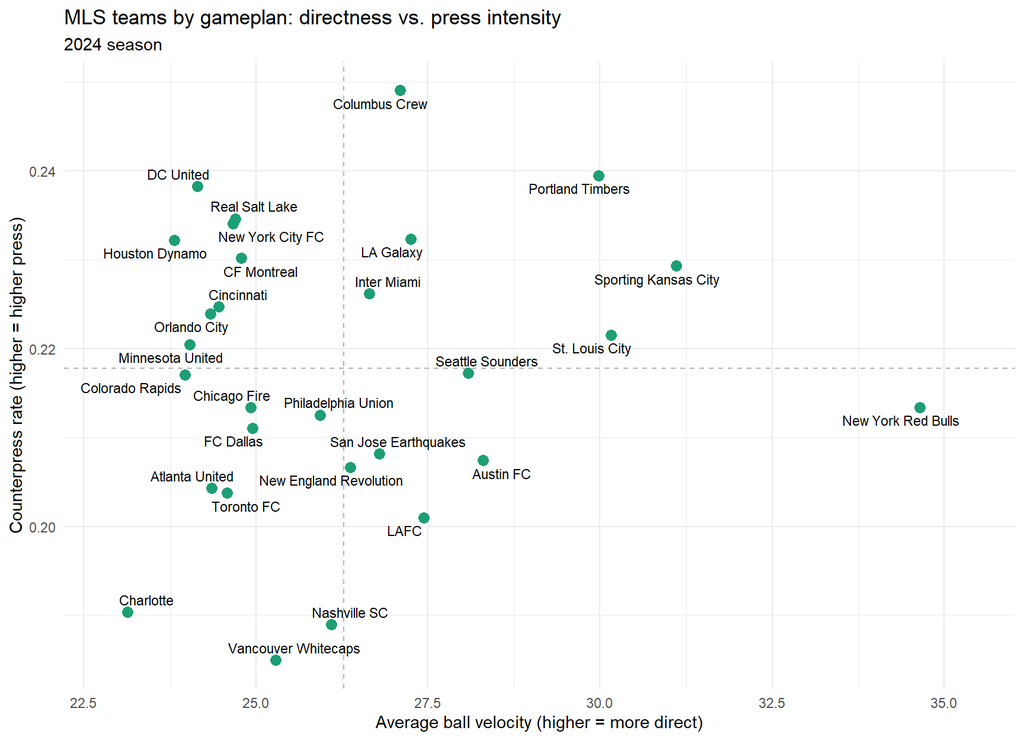

```r
ggplot(team_profile, aes(x = avg_velocity, y = counterpress_rate)) +
  geom_vline(xintercept = mean(team_profile$avg_velocity), linetype = "dashed", color = "gray70") +
  geom_hline(yintercept = mean(team_profile$counterpress_rate), linetype = "dashed", color = "gray70") +
  geom_point(size = 3, color = "#1D9E75") +
  geom_text_repel(aes(label = team), size = 3, max.overlaps = 20, segment.size = 0.2, seed = 42) +
  scale_x_continuous(expand = expansion(mult = c(0.08, 0.12))) +
  labs(
    title = "MLS teams by gameplan: directness vs. press intensity",
    subtitle = "2024 season",
    x = "Average ball velocity (higher = more direct)",
    y = "Counterpress rate (higher = higher press)"
  ) +
  theme_minimal()
```

### Chart 2: where defensive value comes from, by team

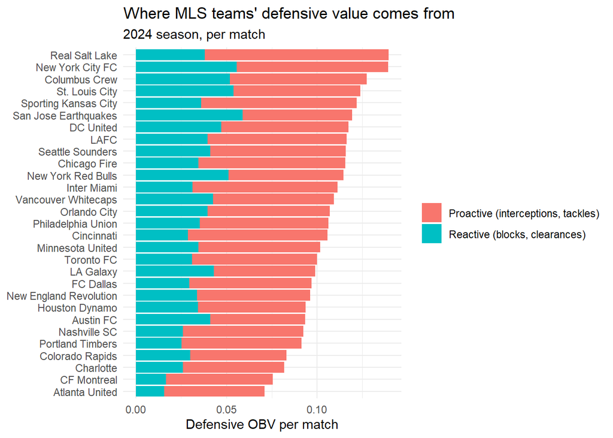

```r
team_profile_long <- team_profile %>%
  select(team, proactive_obv_per_match, reactive_obv_per_match) %>%
  pivot_longer(
    cols = c(proactive_obv_per_match, reactive_obv_per_match),
    names_to = "category", values_to = "obv_per_match"
  ) %>%
  mutate(category = recode(category,
    proactive_obv_per_match = "Proactive (interceptions, tackles)",
    reactive_obv_per_match  = "Reactive (blocks, clearances)"
  ))

ggplot(team_profile_long, aes(x = reorder(team, obv_per_match, sum), y = obv_per_match, fill = category)) +
  geom_col() +
  coord_flip() +
  labs(
    title = "Where MLS teams' defensive value comes from",
    subtitle = "2024 season, per match",
    x = NULL, y = "Defensive OBV per match", fill = NULL
  ) +
  theme_minimal()
```

## Findings & Interpretation

Team that stood out: New York Red Bulls, isolated far right (~34.5 ball velocity, next closest team is ~30). Given RBNY’s historical identity as the pressing team in MLS, it’s notable their counterpress rate here is just middling, as their outlier trait is pure directness, not press intensity.

## Limitations & Next Steps

Missing v8.0.0 fields: The most consequential gap is gk_positioning_xg_suppression and gk_shot_stopping_xg_suppression as both are absent from this export, which means goalkeeper contributions are completely missing from this defensive value analysis. For a question specifically about where defensive value comes from, that’s a real blind spot, an elite shot stopper generates defensive value this dataset can’t see, since it only captures outfield actions (interceptions, tackles, blocks, clearances). The pass clustering fields (pass_cluster_id/_label/_probability) would also have let me test whether “directness” is really one dimension or several distinct passing styles, rather than collapsing it into a single velocity number. shot_execution_xg and its uplift version are offense side metrics, so their absence doesn’t affect this analysis, but would matter for a companion piece on attacking value.

One thing to check with more time: Test the quadrant position against proactive share directly (a regression or correlation) instead of inferring the link across two separate charts. And if the full v8.0.0 schema becomes available, re-run defensive value with GK suppression included, as that’s probably the single biggest missing piece for a “defensive value” question specifically.